# Tercera entrega — Clasificación con las guías OMS 2021

Calidad del aire en CABA · UTN FRC · Grupo 12

Continúa `tercera_entrega_modelado.ipynb`. Con los cortes EPA casi todos los días son *Buena* y el clasificador alcanza una accuracy alta sin detectar episodios. Aquí se reemplaza la etiqueta por las guías OMS 2021 (promedios de 24 h), se justifican los parámetros con una grilla en validación y se interpretan los modelos. Las celdas leen resultados persistidos por `python -m aire_caba.pm10_cierre`.

**Versión final de PM10:** una sola variable nueva (cierre anterior), 56 entradas y ponderación suave. Se conserva íntegro el NO₂ original.

```python
from pathlib import Path
import json
import pandas as pd
from IPython.display import display, Image, Markdown
ROOT = Path.cwd().parent if Path.cwd().name == "notebooks" else Path.cwd()
OUT = ROOT / "outputs/clasificacion_oms_pm10_cierre"
report = json.loads((OUT / "reporte.json").read_text(encoding="utf-8"))
metrics = pd.read_csv(OUT / "metricas_clasificacion.csv")
detail = pd.read_csv(OUT / "metricas_por_clase.csv")
trials = pd.read_csv(OUT / "candidatos_validacion.csv")
pd.set_option("display.max_columns", 20)
print("Cobertura diaria:", json.dumps(report["coverage"], indent=1))
```

```
Cobertura diaria: {
 "CO": {
  "station_days_available": 17108,
  "eligible_station_days": 13599,
  "excluded_station_days": 3509,
  "eligible_without_previous_day": 655
 },
 "NO2": {
  "station_days_available": 17108,
  "eligible_station_days": 13418,
  "excluded_station_days": 3690,
  "eligible_without_previous_day": 540
 },
 "PM10": {
  "station_days_available": 17108,
  "eligible_station_days": 13311,
  "excluded_station_days": 3797,
  "eligible_without_previous_day": 634
 }
}
```

## 1. Por qué cambiar de estándar

| Contaminante | Guía OMS 2021 (24 h) | Objetivo intermedio usado | EPA (alto) |
| --- | --- | --- | --- |
| NO₂ | 25 µg/m³ (≈13 ppb) | 50 µg/m³ (OI-2) | ≥101 ppb |
| PM10 | 45 µg/m³ | — | ≥155 µg/m³ |
| CO | 4 mg/m³ (≈3,5 ppm) | — | ≥9,5 ppm |

Los cortes EPA están pensados para episodios severos; en CABA casi no ocurren con estos contaminantes. La OMS fija valores basados en efectos en la salud a exposiciones más bajas. La etiqueta pasa a responder una pregunta útil: *¿el aire de esta estación cumple hoy la guía sanitaria?*

| pollutant | split category | purga | test | train | validation |
| --- | --- | --- | --- | --- | --- |
| CO | Cumple guía OMS | 10.0 | 1679.0 | 11109.0 | 801.0 |
|  | Supera guía OMS | 0.0 | 0.0 | 0.0 | 0.0 |
| NO2 | Cumple guía OMS | 7.0 | 372.0 | 2457.0 | 87.0 |
|  | Entre guía y objetivo intermedio | 3.0 | 970.0 | 6277.0 | 346.0 |
|  | Supera objetivo intermedio | 0.0 | 322.0 | 2329.0 | 248.0 |
| PM10 | Cumple guía OMS | 8.0 | 1488.0 | 10147.0 | 854.0 |
|  | Supera guía OMS | 0.0 | 48.0 | 734.0 | 32.0 |

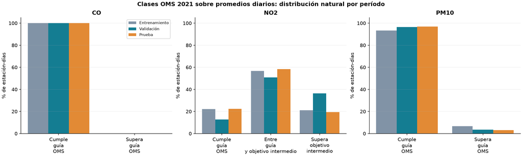

```python
dist = pd.read_csv(OUT / "distribucion_categorias.csv")
display(dist.query("station == 'todas'").pivot_table(index=["pollutant","category"], columns="split", values="count", fill_value=0))
display(Image(filename=str(OUT / "figuras/distribucion_oms.png")))
```

NO₂ queda con tres clases de tamaño comparable y PM10 con una excedencia minoritaria pero evaluable (decenas de días en prueba, cientos en entrenamiento). CO no supera la guía ningún día: no se clasifica.

## 2. Algoritmos, parámetros y selección

Para **NO₂** se mantienen la partición temporal, las entradas diarias y las métricas del modelado original. Se comparan una referencia (clase mayoritaria de entrenamiento), Random Forest y XGBoost. Justificación de la grilla:

- **Random Forest**: 300 árboles (el error se estabiliza; más árboles sólo agregan tiempo), `max_features=0.8` como en el modelado original; se prueba profundidad 8, 12 o sin límite y `min_samples_leaf` 5 o 20 para controlar el sobreajuste con ~11.000 estación-días.
- **XGBoost**: tasa de aprendizaje 0,05 con 300 o 600 árboles (aprendizaje lento, más estable); profundidad 3, 4 o 6 para variar las interacciones permitidas; `subsample` y `colsample_bytree` 0,8 y `reg_lambda=5` como regularización, igual que el modelado original.
- **Ponderación de clases**: exponente 0 (sin pesos), 0,5 (suave) o 1 (balanceado), calculado sólo con entrenamiento. No se remuestrea ni se balancean validación y prueba.
- **Entradas**: `meteo` (meteorología y calendario) o `rezago` (además, el promedio del día anterior).

Se elige por F1 macro de validación (2024) y la elección se guarda antes de evaluar la prueba.

### PM10: modelo final con cierre previo

Se mantienen las 55 entradas originales y se agrega sólo `pm_close_lag1`: el último PM10 publicado de ayer. Ese registro ya resume las 24 horas anteriores. El promedio de ayer (`valor_dia_anterior`) resume todos los registros móviles publicados ese día; ambos aportan información distinta sobre el nivel general y el cierre de la jornada.

XGBoost usa **200 árboles, profundidad 2, `min_child_weight=10`, `reg_lambda=20`, tasa 0,05, submuestreo de filas y columnas 0,8 y semilla 42**. La ponderación es suave (exponente 0,5). Son los parámetros del experimental elegido; aquí no se repite la grilla anterior de PM10.

El corte se calibra en 2024 maximizando las detecciones con un presupuesto de hasta 14 falsas alarmas. Se eligió una versión reducida mediante validación y controles temporales anteriores. El test ya había sido visto en el proyecto: la comparación es exploratoria y no es una nueva evaluación ciega.

La mejora frente al original corresponde al conjunto de cambios de entradas, parámetros, ponderación y umbral; no se atribuye sólo a la variable nueva.

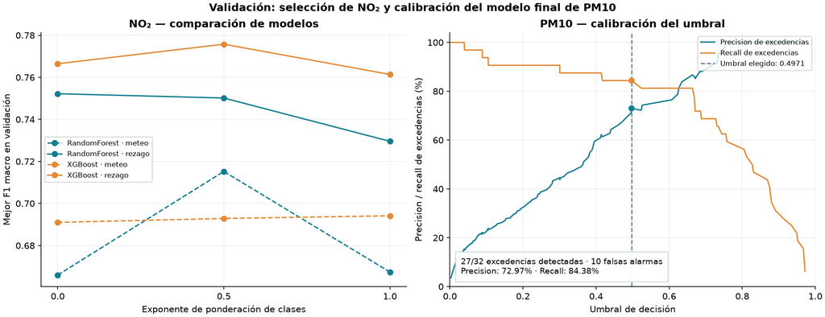

|  | elegido | F1 macro validación |
| --- | --- | --- |
| NO2 | XGBoost_rezago | 0.7758 |
| PM10 | XGBoost_cierre | 0.8869 |

```
NO2 — 10 mejores ensayos de validación
```

|  | model | feature_set | weight_power | max_depth | min_samples_leaf | n_estimators | validation_f1_macro | validation_balanced_accuracy |
| --- | --- | --- | --- | --- | --- | --- | --- | --- |
| 70 | XGBoost | rezago | 0.5 | 6.0 | NaN | 600 | 0.775768 | 0.770199 |
| 69 | XGBoost | rezago | 0.0 | 6.0 | NaN | 600 | 0.766468 | 0.752971 |
| 67 | XGBoost | rezago | 0.5 | 6.0 | NaN | 300 | 0.762047 | 0.761888 |
| 64 | XGBoost | rezago | 0.5 | 4.0 | NaN | 600 | 0.762015 | 0.764935 |
| 68 | XGBoost | rezago | 1.0 | 6.0 | NaN | 300 | 0.761383 | 0.769684 |
| 71 | XGBoost | rezago | 1.0 | 6.0 | NaN | 600 | 0.761063 | 0.765494 |
| 63 | XGBoost | rezago | 0.0 | 4.0 | NaN | 600 | 0.760394 | 0.748355 |
| 57 | XGBoost | rezago | 0.0 | 3.0 | NaN | 600 | 0.759885 | 0.746990 |
| 65 | XGBoost | rezago | 1.0 | 4.0 | NaN | 600 | 0.757715 | 0.775957 |
| 66 | XGBoost | rezago | 0.0 | 6.0 | NaN | 300 | 0.756392 | 0.741074 |

```
PM10 — configuración del modelo final
```

|  | Parámetro | Valor |
| --- | --- | --- |
| 0 | Modelo | XGBoost_cierre |
| 1 | Variables totales | 56 |
| 2 | Única variable nueva | Cierre de PM10 del día anterior |
| 3 | Cantidad de árboles | 200 |
| 4 | Profundidad máxima | 2 |
| 5 | Peso mínimo de hijo | 10 |
| 6 | Tasa de aprendizaje | 0.05 |
| 7 | Regularización L2 | 20 |
| 8 | Submuestreo de filas / columnas | 0.8 / 0.8 |
| 9 | Ponderación | Suave (exponente 0.5) |
| 10 | Umbral de decisión | 0.497096 |

```
PM10 — resultados en validación (2024)
```

|  | Métrica | Valor |
| --- | --- | --- |
| 0 | Casos / excedencias | 886 / 32 |
| 1 | Accuracy | 98.31% |
| 2 | Precision de excedencias | 72.97% |
| 3 | Recall de excedencias | 84.38% |
| 4 | F1 de excedencias | 78.26% |
| 5 | F1 macro | 0.8869 |
| 6 | Accuracy balanceada | 91.60% |
| 7 | Tasa de falsos positivos | 1.17% |
| 8 | TP / FP / FN / TN | 27 / 10 / 5 / 844 |

```
PM10 — controles temporales del modelo final
```

|  | evaluation_year | n | precision_positive | recall_positive | f1_positive | tp | fp | fn |
| --- | --- | --- | --- | --- | --- | --- | --- | --- |
| 0 | 2021 | 695 | 0.500000 | 0.625000 | 0.555556 | 10 | 10 | 6 |
| 1 | 2022 | 669 | 0.770270 | 0.695122 | 0.730769 | 57 | 17 | 25 |
| 2 | 2023 | 914 | 0.584615 | 0.730769 | 0.649573 | 38 | 27 | 14 |

```python
display(Image(filename=str(OUT / "figuras/seleccion_validacion.png")))
display(pd.DataFrame({p: {"elegido": s["selected"], "F1 macro validación": round(s["validation_score"], 4)} for p, s in report["selections"].items()}).T)
cols = ["model","feature_set","weight_power","max_depth","min_samples_leaf","n_estimators","validation_f1_macro","validation_balanced_accuracy"]
for p in ("NO2",):
    print(p, "— 10 mejores ensayos de validación")
    display(trials.query("pollutant == @p").sort_values("validation_f1_macro", ascending=False)[cols].head(10))

print("PM10 — configuración del modelo final")
pm10_meta = report["models"]["PM10"]
params = pm10_meta["parameters"]
configuration = {
    "Modelo": pm10_meta["model"],
    "Variables totales": str(len(pm10_meta["features"])),
    "Única variable nueva": "Cierre de PM10 del día anterior",
    "Cantidad de árboles": str(params["n_estimators"]),
    "Profundidad máxima": str(params["max_depth"]),
    "Peso mínimo de hijo": str(params["min_child_weight"]),
    "Tasa de aprendizaje": f'{params["learning_rate"]:.2f}',
    "Regularización L2": f'{params["reg_lambda"]:g}',
    "Submuestreo de filas / columnas": f'{params["subsample"]:.1f} / {params["colsample_bytree"]:.1f}',
    "Ponderación": f'Suave (exponente {params["weight_power"]:g})',
    "Umbral de decisión": f'{pm10_meta["decision_threshold"]:.6f}',
}
display(pd.DataFrame(configuration.items(), columns=["Parámetro", "Valor"]))
print("PM10 — resultados en validación (2024)")
pm10_validation = pd.read_csv(OUT / "metricas_excedencias_PM10.csv").query(
    "split == 'validation' and station == 'todas'").iloc[0]
validation_summary = {
    "Casos / excedencias": f'{int(pm10_validation["n"])} / {int(pm10_validation["support"])}',
    "Accuracy": f'{pm10_validation["accuracy"]:.2%}',
    "Precision de excedencias": f'{pm10_validation["precision_positive"]:.2%}',
    "Recall de excedencias": f'{pm10_validation["recall_positive"]:.2%}',
    "F1 de excedencias": f'{pm10_validation["f1_positive"]:.2%}',
    "F1 macro": f'{pm10_validation["f1_macro"]:.4f}',
    "Accuracy balanceada": f'{pm10_validation["balanced_accuracy"]:.2%}',
    "Tasa de falsos positivos": f'{pm10_validation["false_positive_rate_positive"]:.2%}',
    "TP / FP / FN / TN": " / ".join(str(int(pm10_validation[k])) for k in ("tp", "fp", "fn", "tn")),
}
display(pd.DataFrame(validation_summary.items(), columns=["Métrica", "Valor"]))
print("PM10 — controles temporales del modelo final")
display(pd.read_csv(OUT / "control_temporal_PM10.csv")[["evaluation_year","n","precision_positive","recall_positive","f1_positive","tp","fp","fn"]])
```

## 3. Evaluación en prueba (2025–2026)

Matriz de confusión, accuracy, precision, recall, F1 y tasa de falsos positivos (FPR = FP / (FP + TN) por clase frente al resto). La referencia mayoritaria muestra cuánto de la accuracy se explica sólo por el desbalance.

PM10 muestra únicamente el modelo final con cierre previo. NO₂ conserva sus resultados anteriores. La precision y el recall de la clase que supera la guía se leen en la tabla por clase, además de los promedios macro.

|  | pollutant | model | n | accuracy | precision_macro | recall_macro | f1_macro | balanced_accuracy | false_positive_rate_macro |
| --- | --- | --- | --- | --- | --- | --- | --- | --- | --- |
| 12 | NO2 | RandomForest_meteo | 1664 | 0.665865 | 0.711553 | 0.629485 | 0.607157 | 0.629485 | 0.206635 |
| 20 | NO2 | XGBoost_meteo | 1664 | 0.638221 | 0.701725 | 0.605948 | 0.573600 | 0.605948 | 0.223356 |
| 28 | NO2 | RandomForest_rezago | 1664 | 0.750601 | 0.744727 | 0.698046 | 0.717034 | 0.698046 | 0.164603 |
| 36 | NO2 | XGBoost_rezago | 1664 | 0.768029 | 0.769117 | 0.727396 | 0.734811 | 0.727396 | 0.151488 |
| 44 | PM10 | XGBoost_cierre | 1536 | 0.958984 | 0.697041 | 0.817540 | 0.741272 | 0.817540 | 0.182460 |

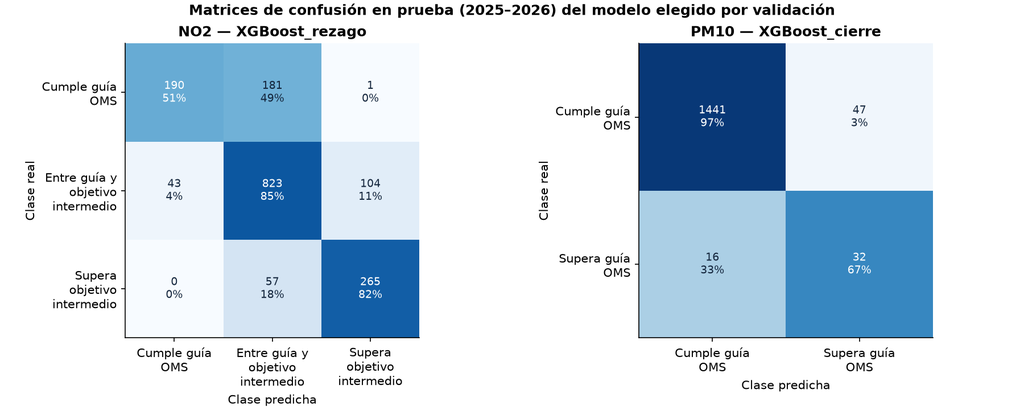

|  | pollutant | model | category | support | precision | recall | f1 | false_positive_rate | tp | fp | fn | tn |
| --- | --- | --- | --- | --- | --- | --- | --- | --- | --- | --- | --- | --- |
| 108 | NO2 | XGBoost_rezago | Cumple guía OMS | 372 | 0.815451 | 0.510753 | 0.628099 | 0.033282 | 190 | 43 | 182 | 1249 |
| 109 | NO2 | XGBoost_rezago | Entre guía y objetivo intermedio | 970 | 0.775683 | 0.848454 | 0.810438 | 0.342939 | 823 | 238 | 147 | 456 |
| 110 | NO2 | XGBoost_rezago | Supera objetivo intermedio | 322 | 0.716216 | 0.822981 | 0.765896 | 0.078241 | 265 | 105 | 57 | 1237 |
| 128 | PM10 | XGBoost_cierre | Cumple guía OMS | 1488 | 0.989019 | 0.968414 | 0.978608 | 0.333333 | 1441 | 16 | 47 | 32 |
| 129 | PM10 | XGBoost_cierre | Supera guía OMS | 48 | 0.405063 | 0.666667 | 0.503937 | 0.031586 | 32 | 47 | 16 | 1441 |

|  | pollutant | model | station | n | accuracy | f1_macro | balanced_accuracy |
| --- | --- | --- | --- | --- | --- | --- | --- |
| 37 | NO2 | XGBoost_rezago | centenario | 571 | 0.746060 | 0.606858 | 0.691573 |
| 38 | NO2 | XGBoost_rezago | cordoba | 542 | 0.778598 | 0.673760 | 0.688489 |
| 39 | NO2 | XGBoost_rezago | la_boca | 551 | 0.780399 | 0.714009 | 0.726393 |
| 45 | PM10 | XGBoost_cierre | centenario | 541 | 0.975970 | 0.753098 | 0.840584 |
| 46 | PM10 | XGBoost_cierre | cordoba | 510 | 0.952941 | 0.714978 | 0.794281 |
| 47 | PM10 | XGBoost_cierre | la_boca | 485 | 0.946392 | 0.753634 | 0.820391 |

```python
cols = ["pollutant","model","n","accuracy","precision_macro","recall_macro","f1_macro","balanced_accuracy","false_positive_rate_macro"]
display(metrics.query("split == 'test' and station == 'todas' and model != 'Mayoria_train'")[cols])
display(Image(filename=str(OUT / "figuras/matrices_oms.png")))
display(detail.query("split == 'test' and station == 'todas' and selected_by_validation")[["pollutant","model","category","support","precision","recall","f1","false_positive_rate","tp","fp","fn","tn"]])
display(metrics.query("split == 'test' and station != 'todas' and selected_by_validation")[["pollutant","model","station","n","accuracy","f1_macro","balanced_accuracy"]])
```

## 4. Patrones e interpretación

TreeSHAP descompone cada predicción en contribuciones de las variables (en log-odds). Se agrupan las columnas one-hot y los resúmenes diarios de una misma variable. Son asociaciones aprendidas por el modelo, no causas.

Para PM10 se recalculan SHAP y sus gráficos con el modelo reducido. Los gráficos por año, mes y día de la semana describen las mismas observaciones que antes; no dependen de cambiar el modelo.

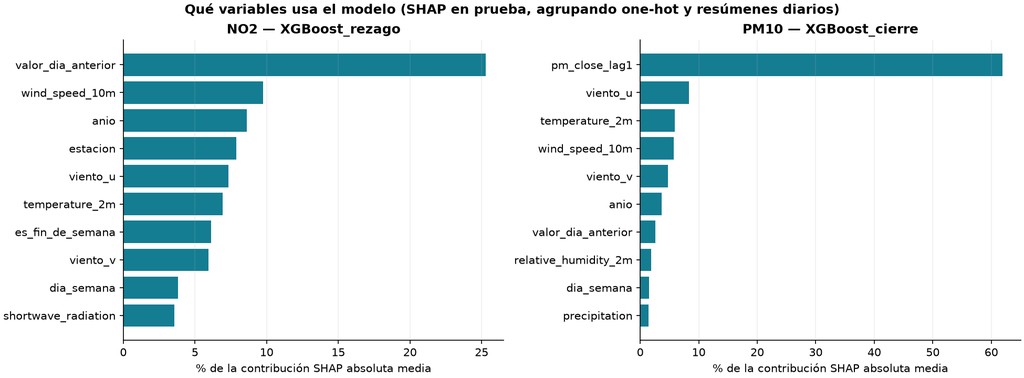

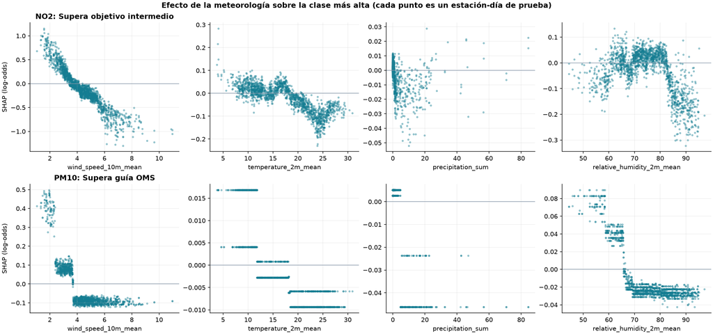

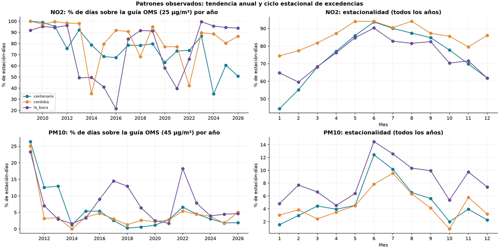

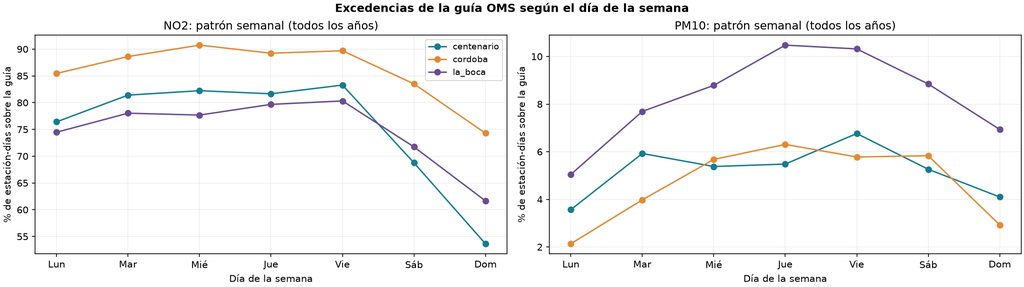

```python
display(Image(filename=str(OUT / "figuras/shap_importancia.png")))
display(Image(filename=str(OUT / "figuras/shap_dependencia.png")))
display(Image(filename=str(OUT / "figuras/patrones_excedencias.png")))

display(Image(filename=str(OUT / "figuras/patrones_dia_semana.png")))
```

```python
display(Markdown((OUT / "resumen_oms.md").read_text(encoding="utf-8").split("## Método")[0]))
```

Clasificación diaria con las guías OMS 2021

- NO2: validación eligió XGBoost_rezago. En prueba, F1 macro 0.735 frente a 0.246 de la clase mayoritaria; balanced accuracy 72.7% y accuracy 76.8%. Variables más usadas (SHAP): valor_dia_anterior (25%), wind_speed_10m (10%), anio (9%), estacion (8%).

- PM10: XGBoost con 56 entradas, pesos suaves y una variable nueva: el cierre previo. En prueba detecta 32 de 48 excedencias, con 47 falsas alarmas. Precision de excedencias 40.51%, recall 66.67%, F1 50.39%; accuracy 95.90% y F1 macro 0.7413.

- CO: 0 estación-días superan la guía OMS de 4 mg/m³ en todo el período; con una sola clase no hay problema de clasificación y CO se analiza sólo con la regresión de la entrega.

## 5. Reproducibilidad

Desde la raíz del proyecto, con el entorno de `requirements-modeling.txt` instalado:

```
python -m aire_caba.pm10_cierre
```

Reentrena sólo el PM10 final con su única variable nueva, calibra el umbral en validación, reproduce sus tres controles temporales y genera resultados, figuras, modelo y esta notebook. **NO₂ se carga del modelo original y se verifica que sus datos y resultados no cambien.** Configuración: `config/pm10_cierre.json`; etiquetas: `config/indices_oms.json`.

Para regenerar únicamente la notebook desde los resultados guardados: `python -m aire_caba.pm10_cierre --report-only`. Para predecir con PM10, cargar su modelo y metadatos y utilizar `predict_daily`: `model.predict()` aplica otro corte.

El cierre previo debe estar publicado al emitir el pronóstico. La meteorología es ERA5 histórica y la etiqueta de PM10 promedia registros móviles de 24 h; faltan validar la disponibilidad operativa, el uso de pronósticos meteorológicos y una evaluación futura independiente. Los resultados corresponden a estación-día.